# Origins

Lewis A. Jones & Miranta Kouvari

Meghalayan

0–0.0042 Ma

Northgrippian

0.0042–0.0082 Ma

Greenlandian

0.0082–0.0117 Ma

Late Pleistocene

0.0117–0.129 Ma

Chibanian

0.129–0.774 Ma

Calabrian

0.774–1.8 Ma

Gelasian

1.8–2.58 Ma

Piacenzian

2.58–3.6 Ma

Zanclean

3.6–5.333 Ma

Messinian

5.333–7.246 Ma

Tortonian

7.246–11.63 Ma

Serravallian

11.63–13.82 Ma

Langhian

13.82–15.97 Ma

Burdigalian

15.97–20.44 Ma

Aquitanian

20.44–23.03 Ma

Chattian

23.03–27.82 Ma

Rupelian

27.82–33.9 Ma

Priabonian

33.9–37.71 Ma

Bartonian

37.71–41.2 Ma

Lutetian

41.2–47.8 Ma

Ypresian

47.8–56 Ma

Thanetian

56–59.2 Ma

Selandian

59.2–61.6 Ma

Danian

61.6–66 Ma

Maastrichtian

66–72.1 Ma

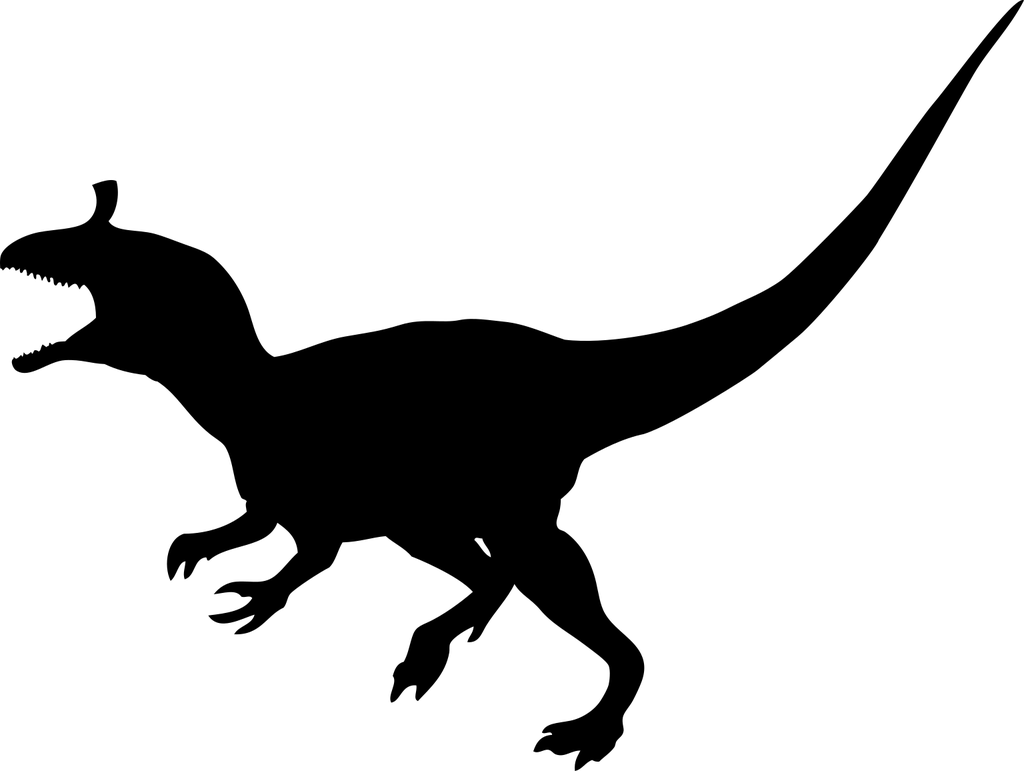

*The Cretaceous/Paleogene extinction event wiped out all non-avian dinosaurs 66 million years ago.*

Campanian

72.1–83.6 Ma

Santonian

83.6–86.3 Ma

Coniacian

86.3–89.8 Ma

Turonian

89.8–93.9 Ma

Cenomanian

93.9–100.5 Ma

Albian

100.5–113 Ma

Aptian

113–121.4 Ma

Barremian

121.4–129.4 Ma

Hauterivian

129.4–132.6 Ma

Valanginian

132.6–139.8 Ma

Berriasian

139.8–145 Ma

Tithonian

145–149.2 Ma

Kimmeridgian

149.2–154.8 Ma

Oxfordian

154.8–161.5 Ma

Callovian

161.5–165.3 Ma

Bathonian

165.3–168.2 Ma

Bajocian

168.2–170.9 Ma

Aalenian

170.9–174.7 Ma

Toarcian

174.7–184.2 Ma

Pliensbachian

184.2–192.9 Ma

Sinemurian

192.9–199.5 Ma

Hettangian

199.5–201.4 Ma

Rhaetian

201.4–208.5 Ma

Norian

208.5–227 Ma

Carnian

227–237 Ma

Ladinian

237–242 Ma

Anisian

242–247.2 Ma

Olenekian

247.2–251.2 Ma

Induan

251.2–251.902 Ma

Changhsingian

251.902–254.14 Ma

Wuchiapingian

254.14–259.51 Ma

Capitanian

259.51–264.28 Ma

Wordian

264.28–266.9 Ma

Roadian

266.9–273.01 Ma

Kungurian

273.01–283.5 Ma

Artinskian

283.5–290.1 Ma

Sakmarian

290.1–293.52 Ma

Asselian

293.52–298.9 Ma

Gzhelian

298.9–303.7 Ma

Kasimovian

303.7–307 Ma

Moscovian

307–315.2 Ma

Bashkirian

315.2–323.2 Ma

Serpukhovian

323.2–330.9 Ma

Visean

330.9–346.7 Ma

Tournaisian

346.7–358.9 Ma

Famennian

358.9–372.2 Ma

Frasnian

372.2–382.7 Ma

Givetian

382.7–387.7 Ma

Eifelian

387.7–393.3 Ma

Emsian

393.3–407.6 Ma

Pragian

407.6–410.8 Ma

Lochkovian

410.8–419.2 Ma

Pridoli

419.2–423 Ma

Ludfordian

423–425.6 Ma

Gorstian

425.6–427.4 Ma

Homerian

427.4–430.5 Ma

Sheinwoodian

430.5–433.4 Ma

Telychian

433.4–438.5 Ma

Aeronian

438.5–440.8 Ma

Rhuddanian

440.8–443.8 Ma

Hirnantian

443.8–445.2 Ma

Katian

445.2–453 Ma

Sandbian

453–458.4 Ma

Darriwilian

458.4–467.3 Ma

Dapingian

467.3–470 Ma

Floian

470–477.7 Ma

Tremadocian

477.7–485.4 Ma

Stage 10

485.4–489.5 Ma

Jiangshanian

489.5–494 Ma

Paibian

494–497 Ma

Guzhangian

497–500.5 Ma

Drumian

500.5–504.5 Ma

Wuliuan

504.5–509 Ma

Stage 4

509–514 Ma

Stage 3

514–521 Ma

Stage 2

521–529 Ma

Fortunian

529–538.8 Ma